Data Analysis Nanodegree

# Project 4: Analyzing TMDb movie data

*by Cristian Segura Villalobos*

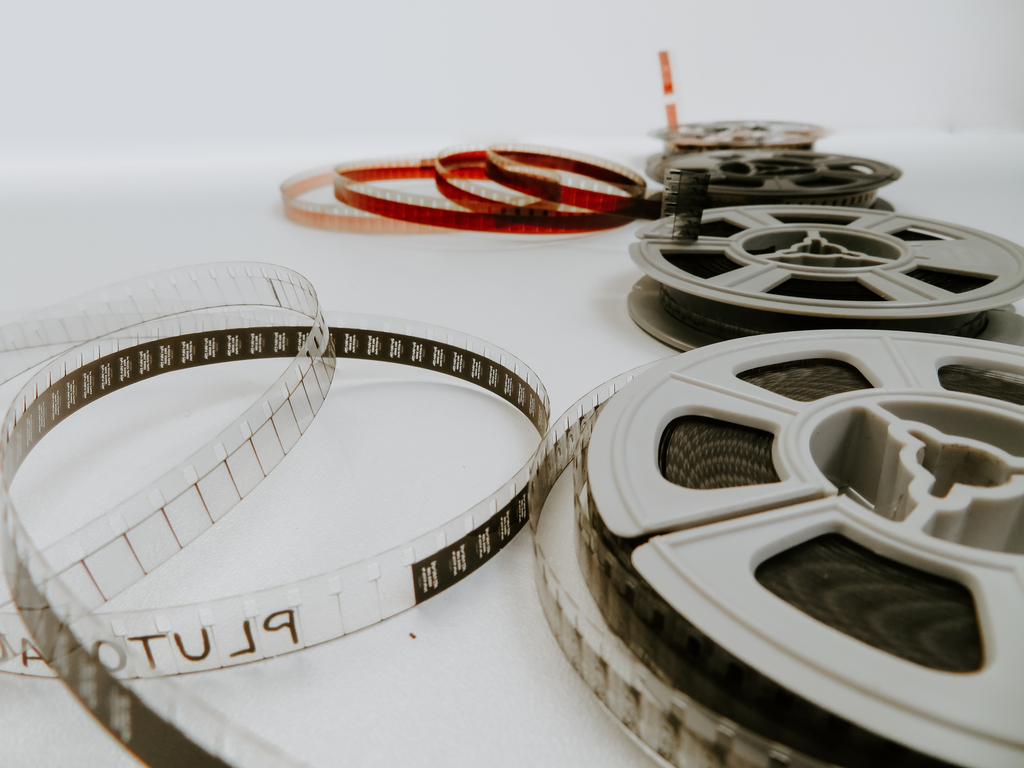

Photo by [Denise Jans](https://unsplash.com/@dmjdenise?utm_source=unsplash&utm_medium=referral&utm_content=creditCopyText) on [Unsplash](https://unsplash.com/s/photos/movies?utm_source=unsplash&utm_medium=referral&utm_content=creditCopyText)

- Introduction
- Data Wrangling
- Exploratory Data Analysis
- Conclusions

## Introduction

In this report, you will find an analysis about "The movie database". To do this, I will start by taking a look at the dataset and brainstorming what questions could be answered. Then, I will use pandas and NumPy to answer the questions I'm most interested in, and share the answers.

The findings that you can find here are tentative, and this project is open-ended in that we are not looking for one right answer.

### Chosen dataset

Since I'm a big fan of movies, I selected ["TMDb database"](https://d17h27t6h515a5.cloudfront.net/topher/2017/October/59dd1c4c_tmdb-movies/tmdb-movies.csv) dataset from a list included in the following [document](https://s3.amazonaws.com/video.udacity-data.com/topher/2018/July/5b57919a_data-set-options/data-set-options.pdf).

This dataset contains information about 10,000 movies collected from The Movie Database (TMDb),including user ratings and revenue.

- Certain columns, like ‘cast’and ‘genres’, contain multiple values separated by pipe (|) characters.
- There are some odd characters in the ‘cast’ column. These will be leaved as they are.
- The final two columns ending with “_adj” show the budget and revenue of the associated movie in terms of 2010 dollars, accounting for inflation over time.

### Getting Organized

I have selected to submit the project in this Jupyter notebook, so you will find in here:

- The code I wrote, and
- The report of my findings.

### To analyze the data: brainstorming of questions

Question given with the data set:

- Which genres are most popular from year to year?
- What kinds of properties are associated with movies that have high revenues?

My personal questions:

- Is there any relationship between popularity and budget?
- What kinds of properties are associated with movies that have high vote?

### Sharing findings

The report of my findings and the analysis is shown as a markdown cell after every code cell.

This report contains also a pdf version.

## Data Wrangling

In this section, you will find:

- How I load and explore the data,
- How I check for cleanliness, and
- How I trim and clean the data

### How I load and explored the data

```python
# Importing neccesary libraries
import pandas as pd
import numpy as np
import matplotlib.pyplot as plp
pd.options.display.max_rows = 200
pd.options.display.max_columns = 50
%matplotlib inline
```

#### Reading the csv file

```python
df = pd.read_csv("tmdb-movies.csv")
df.head(1)
```

|  | id | imdb_id | popularity | budget | revenue | original_title | cast | homepage | director | tagline | keywords | overview | runtime | genres | production_companies | release_date | vote_count | vote_average | release_year | budget_adj | revenue_adj |
| --- | --- | --- | --- | --- | --- | --- | --- | --- | --- | --- | --- | --- | --- | --- | --- | --- | --- | --- | --- | --- | --- |
| 0 | 135397 | tt0369610 | 32.985763 | 150000000 | 1513528810 | Jurassic World | Chris Pratt\|Bryce Dallas Howard\|Irrfan Khan\|Vi... | http://www.jurassicworld.com/ | Colin Trevorrow | The park is open. | monster\|dna\|tyrannosaurus rex\|velociraptor\|island | Twenty-two years after the events of Jurassic ... | 124 | Action\|Adventure\|Science Fiction\|Thriller | Universal Studios\|Amblin Entertainment\|Legenda... | 6/9/15 | 5562 | 6.5 | 2015 | 1.379999e+08 | 1.392446e+09 |

**Analysis**

Here, we can note that:

- "cast", "genres" and "production_companies" column have a list of actors/genre separated by "|". So if we need to make any analysis about the individual actor/actress, production company or genre we will need to separate them

#### Exploring the dataset

Here, I will perform a series of basic commands to: know what type of data there is in every column, how much non-null values there are and how is distributed the information per column.

```python
# General information about data types and null values
df.info()
```

```
<class 'pandas.core.frame.DataFrame'>
RangeIndex: 10866 entries, 0 to 10865
Data columns (total 21 columns):
 #   Column                Non-Null Count  Dtype
---  ------                --------------  -----
 0   id                    10866 non-null  int64
 1   imdb_id               10856 non-null  object
 2   popularity            10866 non-null  float64
 3   budget                10866 non-null  int64
 4   revenue               10866 non-null  int64
 5   original_title        10866 non-null  object
 6   cast                  10790 non-null  object
 7   homepage              2936 non-null   object
 8   director              10822 non-null  object
 9   tagline               8042 non-null   object
 10  keywords              9373 non-null   object
 11  overview              10862 non-null  object
 12  runtime               10866 non-null  int64
 13  genres                10843 non-null  object
 14  production_companies  9836 non-null   object
 15  release_date          10866 non-null  object
 16  vote_count            10866 non-null  int64
 17  vote_average          10866 non-null  float64
 18  release_year          10866 non-null  int64
 19  budget_adj            10866 non-null  float64
 20  revenue_adj           10866 non-null  float64
dtypes: float64(4), int64(6), object(11)
memory usage: 1.7+ MB
```

**Analysis**

```python
# Quantity of registers and columns
df.shape
```

```
(10866, 21)
```

**Analysis**

This dataset contains 10866 rows and 21 columns

```python
# General statistical information per numerical columns
df.describe()
```

|  | id | popularity | budget | revenue | runtime | vote_count | vote_average | release_year | budget_adj | revenue_adj |
| --- | --- | --- | --- | --- | --- | --- | --- | --- | --- | --- |
| count | 10866.000000 | 10866.000000 | 1.086600e+04 | 1.086600e+04 | 10866.000000 | 10866.000000 | 10866.000000 | 10866.000000 | 1.086600e+04 | 1.086600e+04 |
| mean | 66064.177434 | 0.646441 | 1.462570e+07 | 3.982332e+07 | 102.070863 | 217.389748 | 5.974922 | 2001.322658 | 1.755104e+07 | 5.136436e+07 |
| std | 92130.136561 | 1.000185 | 3.091321e+07 | 1.170035e+08 | 31.381405 | 575.619058 | 0.935142 | 12.812941 | 3.430616e+07 | 1.446325e+08 |
| min | 5.000000 | 0.000065 | 0.000000e+00 | 0.000000e+00 | 0.000000 | 10.000000 | 1.500000 | 1960.000000 | 0.000000e+00 | 0.000000e+00 |
| 25% | 10596.250000 | 0.207583 | 0.000000e+00 | 0.000000e+00 | 90.000000 | 17.000000 | 5.400000 | 1995.000000 | 0.000000e+00 | 0.000000e+00 |
| 50% | 20669.000000 | 0.383856 | 0.000000e+00 | 0.000000e+00 | 99.000000 | 38.000000 | 6.000000 | 2006.000000 | 0.000000e+00 | 0.000000e+00 |
| 75% | 75610.000000 | 0.713817 | 1.500000e+07 | 2.400000e+07 | 111.000000 | 145.750000 | 6.600000 | 2011.000000 | 2.085325e+07 | 3.369710e+07 |
| max | 417859.000000 | 32.985763 | 4.250000e+08 | 2.781506e+09 | 900.000000 | 9767.000000 | 9.200000 | 2015.000000 | 4.250000e+08 | 2.827124e+09 |

**Analysis**

```
array([[<matplotlib.axes._subplots.AxesSubplot object at 0x000001C446A9F3C8>,
      dtype=object)
```

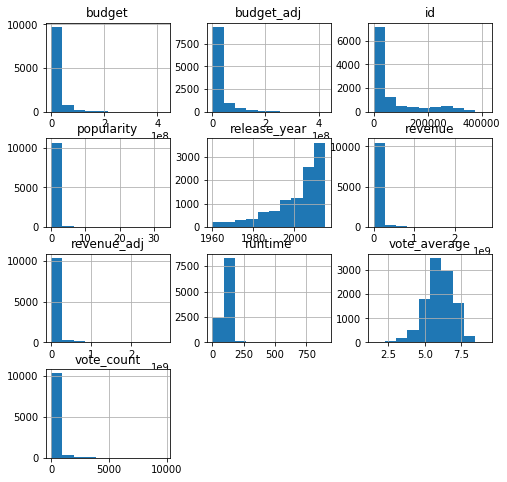

```python
# Exploring histograms

df.hist(figsize=(8,8))
```

[output not shown]

[output not shown]

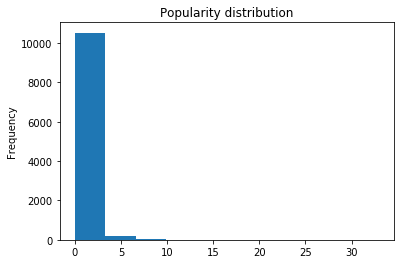

```python
# Exploring numerical values

## Checking popularity values distribution
display(df["popularity"].describe())
display(df["popularity"].value_counts().sort_index(ascending=False))
df["popularity"].plot(kind="hist", title="Popularity distribution", x="label")
```

**Analysys**